# SIBER introduction

12 December 2015

## Inference from d-space

- Isotopes are like naturally occurring PCA analyses
- They are two axes, behind which lie multiple biotic and physical factors
- d15N tells us a lot about trophic level for example
- d13C can tell us about marine Vs terrestrial among other scenopoetic factors
- Idea is that isotopic niche correlates in some way with ecological niche

## Specialists Vs generalists

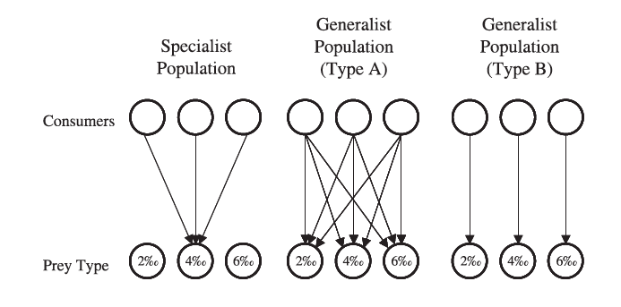

Bearhop, Adam, Waldron, Fuller & MacLeod. 2004. Determining trophic niche width: a novel approach using stable isotope analysis. J Anim Ecol.

## Drivers of niche width

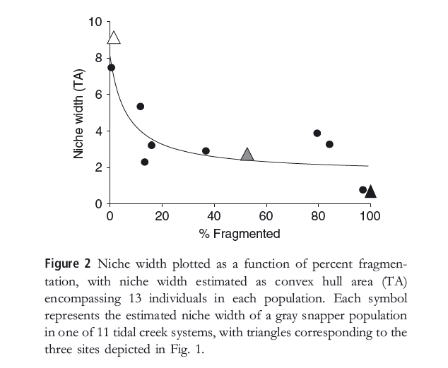

Layman et al. 2007. Niche width collapse in a resilient top predator following ecosystem fragmentation.

## Invasive species

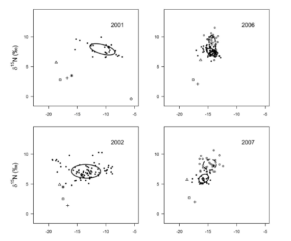

Jackson, M.C. et al. 2012. Population-Level Metrics of Trophic Structure Based on Stable Isotopes and Their Application to Invasion Ecology. PLoSONE.

## The problem with convex hulls

They can only get bigger.

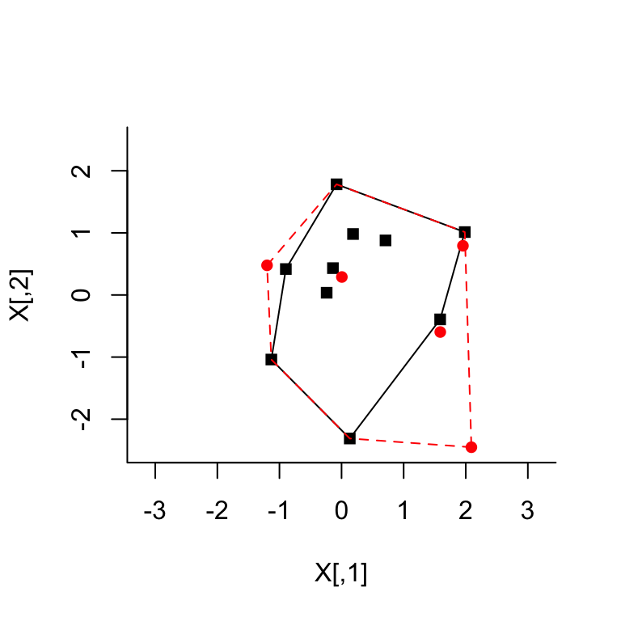

## SIBER

[figure not shown]

## The standard ellipse

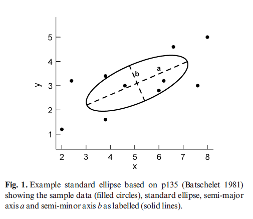

- a = semi-major axis length
- b = semi-minor axis length
- `Area = pi*a*b`
- contains ~= 40% of the data
- located by the means of X and Y
- shape and size determined by covariance matrix Sigma

## Uncertainty of the ellipse

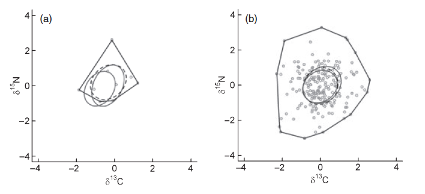

## Sample size, ellipses and hulls

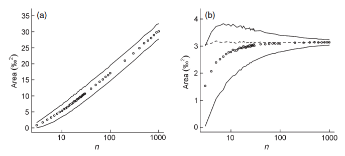

a = Hulls & b = Ellipses

## Sample size and bias in ellipse estimation

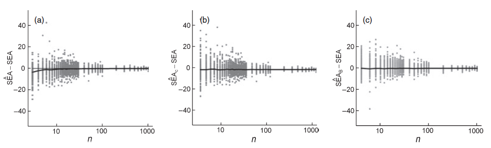

a = SEA, b = SEAc and c = SEA_B

## SIBER has two quite different routines

- Question is: do you want to compare populations within a community, or make comparisons across entire communities?

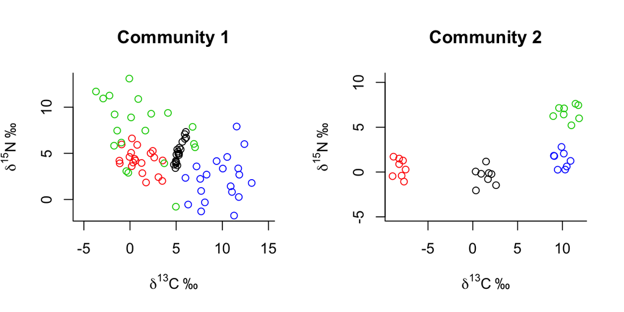

## Comparisons of populations

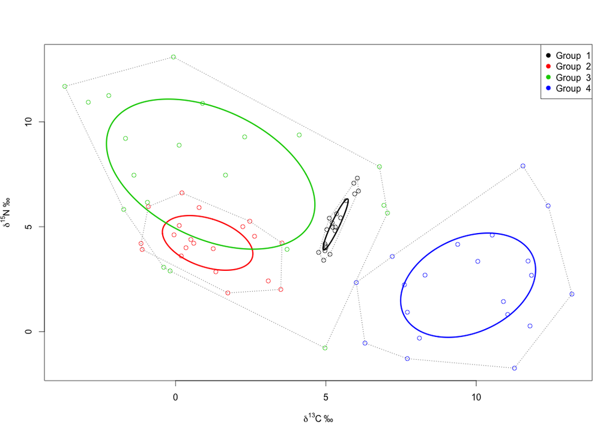

## SIBER output

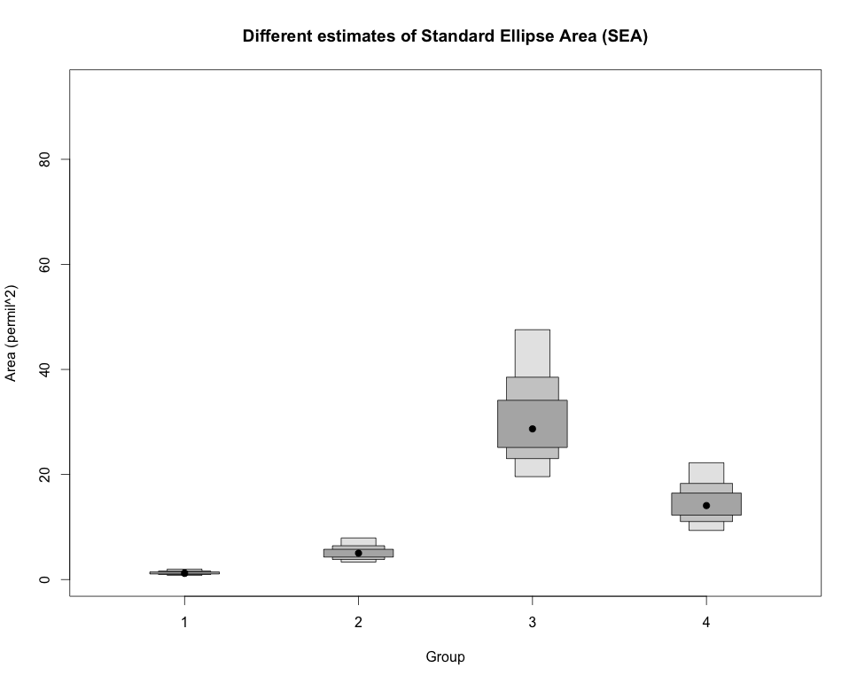

## Comparisons of communities

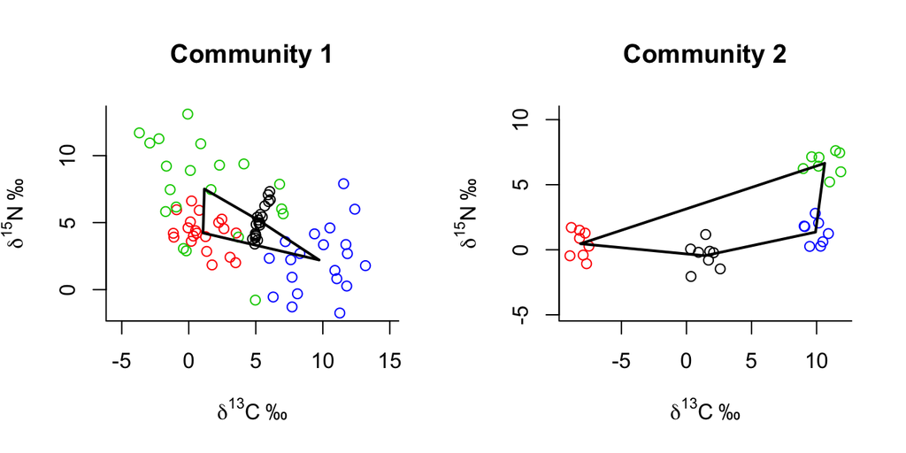

## Layman metrics

- **TA** - the area of convex hull containing, in the case of SIBER, the means of the populations that comprise the community.
- **dN_range** - the distance in units between the min and max y-axis populations means which is most often d15Nitrogen in ecological studies.
- **dC_range** - the distance in units between the min and max x-axis population means which is most often d13Carbon in ecological studies.
- **CD** - the mean distance to centroid from the means
- **MNND** - the mean nearest neighbour distance of the means
- **SDNND** - the standard deviation of the nearest neighbour distance

## Calculate metrics based on ellipses fitted to populations

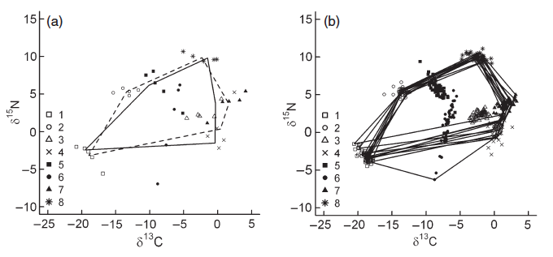

## Bayesian Convex Hulls (TA)

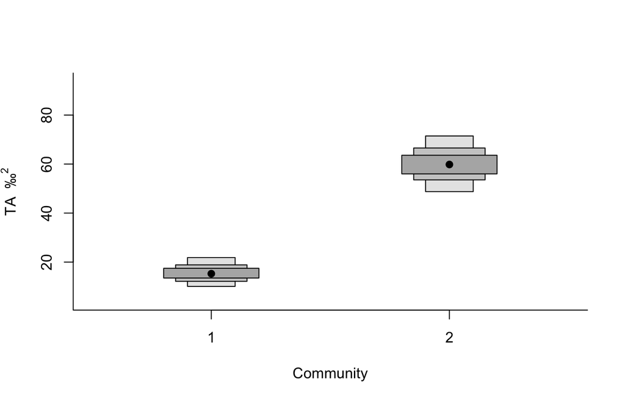

## And the other 5 metrics

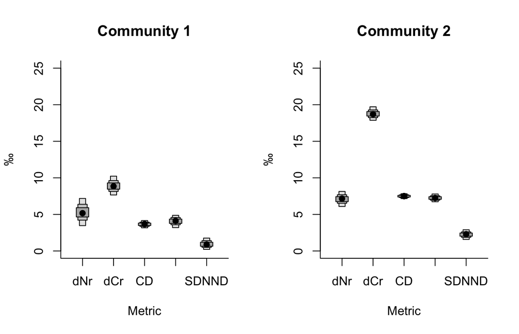